# Introduction to RE2

## Table of Content

1. What is Regular Expression
2. When to use RE
3. How to use RE with re2r
4. RE packages in R
5. Benchmark

## What is Regular Expression

It is a way to search for matches in strings. This is done by searching with “patterns” through the string.

You probably know the `*` and `?` charachters used in the dir command on the command line. The `*` character means “zero or more arbitrary characters” and the `?` means “one arbitrary character”.

When using a pattern like `text?.*`, it will find files like `textf.txt`, `text1.R`, and `text9.Rmd`.

This is exactly the way RE works, and RE supplies much more patterns.

## When to use RE

Example usages could be:

1. Remove all occurences of a specific tag from text file
2. Check whether an e-mail address is well-formed

Basically we can do the following operations on a string with REs:

### 1. Test for a pattern

Search through a string for a pattern, and return boolean result or matched substrings.

### 2. Extract a substring

Search for a substring, and return that substring.

### 3. Replace a substring

Search for a substring that matches a pattern, and replace it by another string.

## How to use RE with re2r

Here is a quick overview over the most common methods on how to execute a regular expression in **re2r**.

### 1. Search a string

```r
re2_detect(string, pattern)
```

Searches the string expression for a pattern and returns boolean result.

```r
re2_detect("this is just one test", "(o.e)")
```

```
## [1] TRUE
```

`.` stands for **any character, possibly including newline** . For more syntax, you can check out the RE2 Syntax vignette.

Here is an example of email pattern.

```r
show_regex("\\b[a-zA-Z0-9._%+-]+@[a-zA-Z0-9.-]+\\.[a-zA-Z]{2,4}\\b", width = 670, height = 280)
```

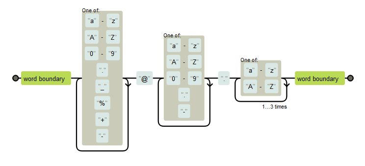

show_regex

```r
re2_detect("test@gmail.com", "\\b[a-zA-Z0-9._%+-]+@[a-zA-Z0-9.-]+\\.[a-zA-Z]{2,4}\\b")
```

```
## [1] TRUE
```

```r
re2_match(string, pattern)
```

This function will return the capture groups in `()`.

```r
(res = re2_match("this is just one test", "(o.e)"))
```

```
##      .match .1
## [1,] "one"  "one"
```

```r
str(res)
```

```
##  chr [1, 1:2] "one" "one"
##  - attr(*, "dimnames")=List of 2
##   ..$ : NULL
##   ..$ : chr [1:2] ".match" ".1"
```

The return result is a character matrix. `.1` is the first capture group and it is unnamed group.

We can create named capture group with `(?P<name>pattern)` syntax.

```r
(res = re2_match("this is just one test", "(?P<testname>this)( is)"))
```

```
##      .match    testname .2
## [1,] "this is" "this"   " is"
```

```r
str(res)
```

```
##  chr [1, 1:3] "this is" "this" " is"
##  - attr(*, "dimnames")=List of 2
##   ..$ : NULL
##   ..$ : chr [1:3] ".match" "testname" ".2"
```

If there is no capture group, the matched origin strings will be returned.

```r
test_string = c("this is just one test", "the second test");
(res = re2_match(test_string, "is"))
```

```
##      .match
## [1,] "is"
## [2,] NA
```

```r
str(res)
```

```
##  chr [1:2, 1] "is" NA
##  - attr(*, "dimnames")=List of 2
##   ..$ : NULL
##   ..$ : chr ".match"
```

`re2_match_all()` will return the all of patterns in a string instead of just the first one.

```r
re2_match_all(
            string = c("this is test",
                      "this is test, and this is not test",
                      "they are tests"),
            pattern = "(?P<testname>this)( is)")
```

```
## [[1]]
##      .match    testname .2
## [1,] "this is" "this"   " is"
##
## [[2]]
##      .match    testname .2
## [1,] "this is" "this"   " is"
## [2,] "this is" "this"   " is"
##
## [[3]]
##      .match testname .2
```

### 2. Replace a substring

```r
re2_replace(string, pattern, rewrite)
```

Searches the string “input string” for the occurence(s) of a substring that matches ‘pattern’ and replaces the found substrings with “rewrite text”.

```r
input_string = "this is just one test";
new_string = "my"
re2_replace(input_string, "(o.e)", new_string)
```

```
## [1] "this is just my test"
```

### 3. Extract a substring

```r
re2_extract(input, pattern)
```

Searches the string “input string” for the occurence(s) of a substring that matches ‘pattern’ and return the found substrings with “rewrite text”.

```r
re2_extract("yabba dabba doo", "yabba")
```

```
## [1] "yabba"
```

```r
re2_extract("test@me.com", "(.*)@([^.]*)")
```

```
## [1] "test@me"
```

### 4. Pre-compiled RE

We can create a regular expression object (RE2 object) from a string. It will reduce the time to parse the syntax of the same pattern.

And this will also give us more option for the pattern. run `help(re2)` to get more detials.

```r
regexp = re2("test", case_sensitive = FALSE)
print(regexp)
```

```
## re2 pre-compiled regular expression
##
## pattern: test
## number of capturing subpatterns: 0
## capturing names with indices:
## .match
## expression size: 10
```

### 5. Multithread

Use `parallel` option to enable multithread feature. It will improve performance for large inputs with a multi core CPU.

```r
re2_match(string, pattern, parallel = T)
```

## RE packages in R

### 1. Base R with **PCRE**

Base R functions such as `regexpr` use [PCRE](http://www.pcre.org/) when given the `perl = TRUE` argument. PCRE includes many useful features, such as [named capture](https://github.com/tdhock/regex-tutorial#motivation-for-using-named-capture-regular-expressions-5-minutes), but has an exponential time complexity.

### 2. Base R with **TRE**

Base R functions such as `regexpr` use [TRE](https://github.com/laurikari/tre) when given the `perl = FALSE` argument. TRE has a polynomial time complexity but does not include named capture groups.

### 3. **stringi** with **ICU**

`stringr::str_match` and `stringi::stri_match` use the regex engine from the ICU library, which has an exponential time complexity. The stringi package does not support named capture yet as such a feature set is still considered as [experimental in ICU](https://github.com/hadley/stringr/pull/16).

### 4. **re2r** with **RE2**

RE2 is a primarily DFA based regexp engine from Google that is very fast at matching large amounts of text. It is has a `polynomial time complexity` (or `fast and scalable` in general case), but it does not support `look behind` and some regular expression features.

### Above all

Although being slightly different to use (because of the design of the engines), all are quite similar to **Perl**’s implementation of REs.

## Benchmarks

Benchmarks are disabled by default for CRAN. See https://qinwenfeng.com/re2r_doc for the results by Travis-CI.